# Dimensionality Reduction of pizza dataset

#### T-SNE

T-SNE stands for t-Distributed Stochastic Neighbor Embedding. In a nutshell, The t-SNE algorithm calculates a similarity measure between pairs of instances in the high dimensional space and in the low dimensional space. Then, it tries to optimize these two similarity measures using a cost function. The algorithm is able to provide a 2D or 3D visual representation of the data. That’s why, it might be useful, in order to better understanding of high-dimensional data or even to classification/regression purposes.

However, using my dataset as an example, it may turn out that I have not presented the whole capabilities of this algorithm. Nevertheless, for the purpose of this exercise and my for self-development, I decided to implement it into my dataset and see how it would work and if it would indicate any differences from PCA.

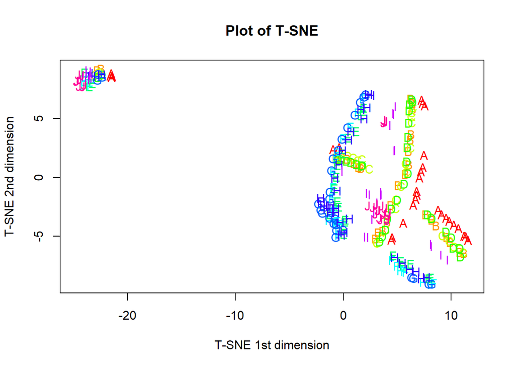

```r
#library(Rtsne)
set.seed(42) # to ensure reproducibility

colors = rainbow(length(unique(pizza_non_sc_no_dp$brand)))
names(colors) = unique(pizza_non_sc_no_dp$brand)

pizza_matrix <- as.matrix(pizza_non_sc_no_dp[, -1])
tsne <- Rtsne::Rtsne(pizza_matrix, check_duplicates = FALSE, pca = FALSE, perplexity=30, theta=0.5, dims=3)

plot(tsne$Y, t='n',
     main = "Plot of T-SNE",
     xlab = "T-SNE 1st dimension",
     ylab = "T-SNE 2nd dimension")
text(tsne$Y, labels=pizza_non_sc_no_dp$brand, col=colors[pizza_non_sc_no_dp$brand])
```

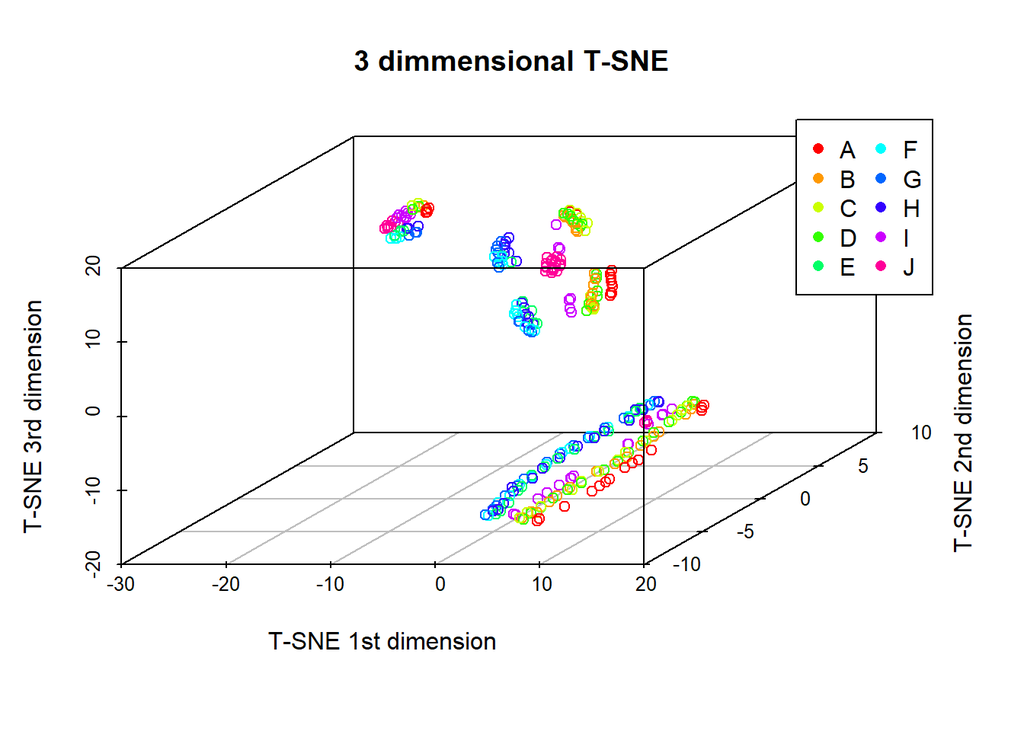

```r
#library(scatterplot3d)
scatterplot3d::scatterplot3d(x=tsne$Y[,1],y=tsne$Y[,2],z=tsne$Y[,3], color = colors[pizza_non_sc_no_dp$brand],
                             main = "3 dimmensional T-SNE",
                             xlab = "T-SNE 1st dimension",
                             ylab = "T-SNE 2nd dimension",
                             zlab = "T-SNE 3rd dimension")
legend("topright", legend = c("A","B","C","D","E","F","G","H","I","J"),
      col =  colors, xpd = TRUE, horiz = FALSE, ncol = 2, pch = 16)
```

## References

https://towardsdatascience.com/an-introduction-to-t-sne-with-python-example-5a3a293108d1

https://builtin.com/data-science/step-step-explanation-principal-component-analysis

https://docs.displayr.com/wiki/Kaiser_Rule

https://github.com/jkrijthe/Rtsne/issues/12

https://en.wikipedia.org/wiki/Principal_component_analysis